# Cause of Death

## Question 13

```r
data %>% group_by(Year) %>% filter(State == "New York" & Cause == "Chronic lower respiratory diseases (J40-J47)") %>% select(Deaths) %>% arrange(desc(Deaths))
```

```
## # A tibble: 22 × 2
## # Groups:   Year [22]
##     Year Deaths
##    <dbl>  <dbl>
##  1  1999  12866
##  2  2017  12864
##  3  2018  12806
##  4  2002  12688
##  5  2015  12680
##  6  2012  12576
##  7  2013  12556
##  8  2001  12482
##  9  2008  12474
## 10  2011  12428
## # … with 12 more rows
## # ℹ Use `print(n = ...)` to see more rows
```

The most likely year of death is 1999

```r
deaths = sum(data %>% filter(Year == "1999" & State == "New York" & Cause == "Chronic lower respiratory diseases (J40-J47)") %>% select(Deaths))
totalDeaths = sum(data %>% filter(State == "New York" & Cause == "Chronic lower respiratory diseases (J40-J47)") %>% select(Deaths))
prob = deaths/totalDeaths
```

The probability of dying in 1999 if the cause of death is chronic lower respiratory diseases and the state is New York is 0.0474582.

## Question 14

```r
deaths = sum(data %>% filter(Cause == "Malignant neoplasms (C00-C97)") %>% select(Deaths))
totalDeaths = sum(data %>% select(Deaths))
prob = deaths/totalDeaths
```

The probability of having died of cancer is 0.2663998.

## Question 15

## Question 16

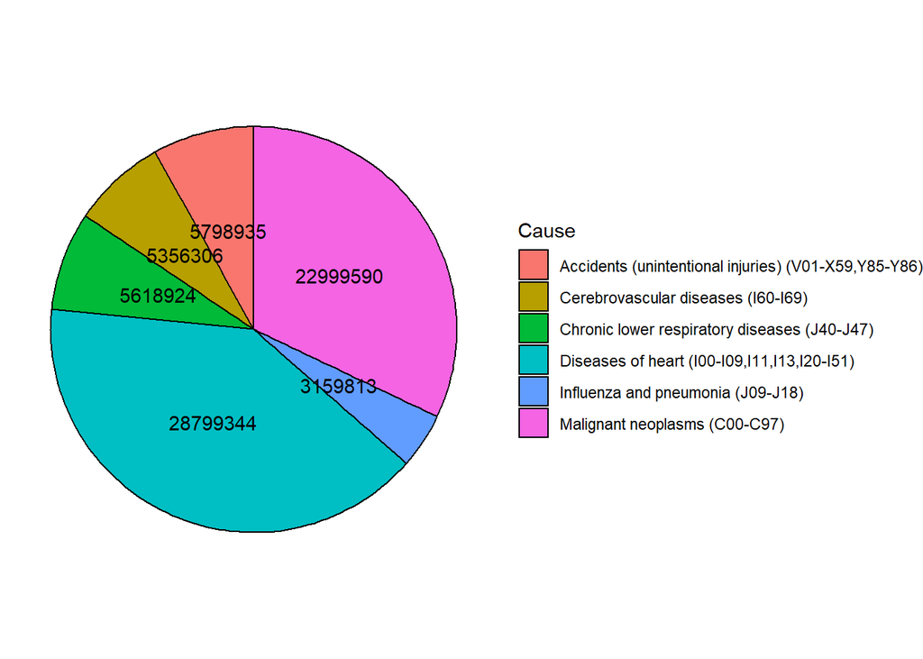

```r
topDeaths = head(data %>% group_by(Cause) %>% summarize(total = sum(Deaths)) %>% arrange(desc(total)), n=6)
ggplot(data = topDeaths, aes(x="", y=total, fill=Cause)) +
  geom_col(width = 1, color="black") +
  coord_polar("y", start=0) +
  theme_void() +
  geom_text(aes(label = total), position = position_stack(vjust = 0.5))
```

## Question 17

# Part 1

## 1. Describe in a few sentences two different groups, industries, sectors, or other areas of society that would experience a loss due to an increase in mortality rate in the United States.

## 2. Describe in no more than a few sentences an example of how insurance may be used to help mitigate or manage the losses you noted in question 1.

## 3. Describe in no more than a few sentences an example of how implementing new policies, procedures, or systems to help change behaviors of those involved to help mitigate or manage the losses you noted in this scenario.

## 4. Describe in no more than a few sentences an example of how those involved in the scenario may be able to help modify the possible outcomes to help mitigate or manage the losses you noted.

# Part 2